# Geospatial data types, CRS, and NASS

# Geospatial data types

## 2 main geospatial data types

1. Vector
2. Raster

## Vector formats

Commonly known as **shapefiles** (ESRI nomenclature)

| Format | Extension |
| --- | --- |
| ESRI shapefile | `.shp`, `.shx`, `.dbf.`, `.prj` |
| GeoJSON | `.json`, `.geojson` |
| KML | `.kml`, `.kmz` |

## Vector types

Vector data comprises points, lines, polygons, and their combinations.

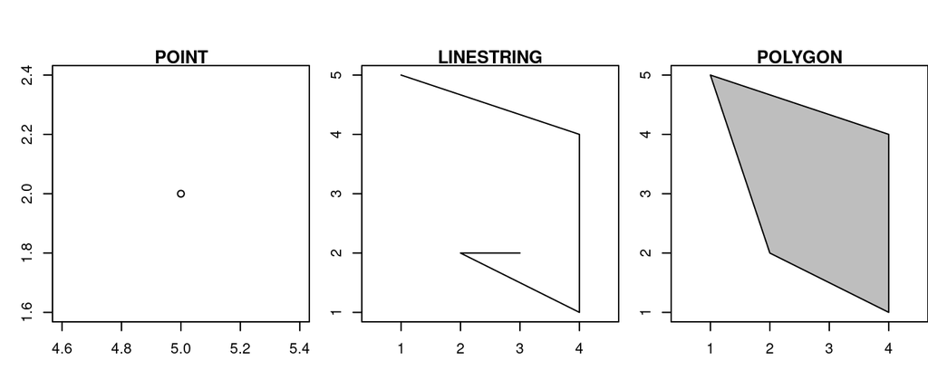

## Vector data in R

- package `sp`:
  - first to be created
  - complicated file structure (data + spatial info)
  - difficult to manipulate data frame
  - not pipeable
- package `sf`:
  - newer than `sp`
  - addresses `sp` shortcomings
  - **this is what we will use**

## Raster formats

Most common in ag is **.tif**.

| Format | Extension |
| --- | --- |
| TIFF/COG | `.tiff`, `.tif`, `.tff` |
| ASCII Grid | `.asc` |
| Bitmap | `.bmp` |

Full list [here](https://pro.arcgis.com/en/pro-app/latest/help/data/imagery/supported-raster-dataset-file-formats.htm)

## Raster types

Raster data is normally originated from an imagery source OR point-based interpolated map/grid (continuous coverage).

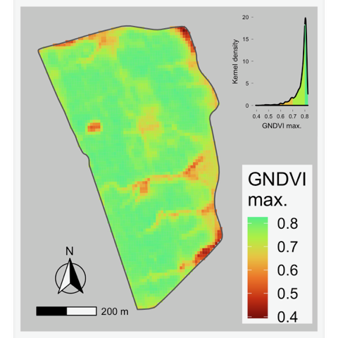

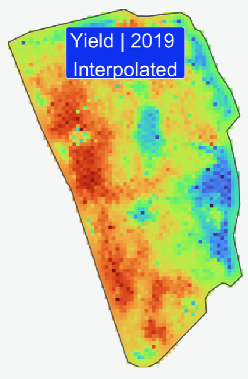

## Raster data in R

- packages `raster` and `terra`:
  - `raster` was first in R
  - `terra` newer, faster, not pipeable
- package `stars`:
  - newer than `raster`
  - pipeable
  - shares concepts with `sf`
  - **this is what we will use** (for the most part)

## Vector vs. Raster

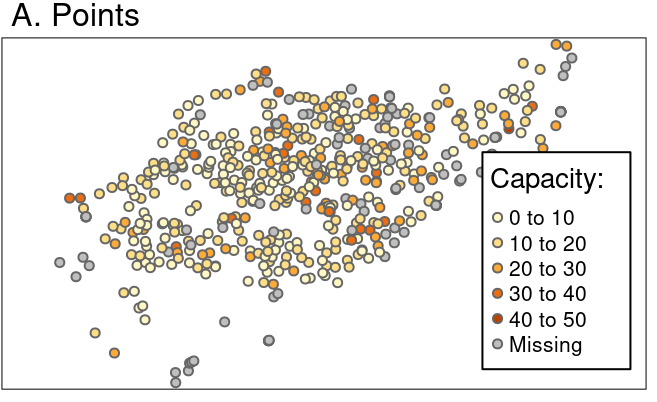

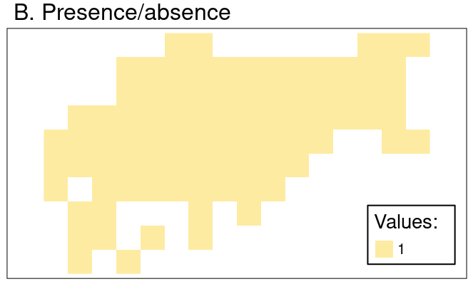

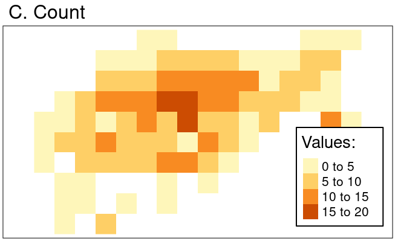

# Coordinate reference systems (crs)

Geographic vs. Projected

## Geographic coordinate systems

- Lat/Long (WGS84) most common

[figure not shown]

## Projected coordinate system

- Universal Transverse Mercator (UTM) most common
- UTM has **zones**
- In GA, 2 zones (16N, **17N**)

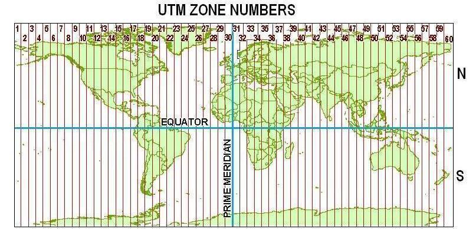

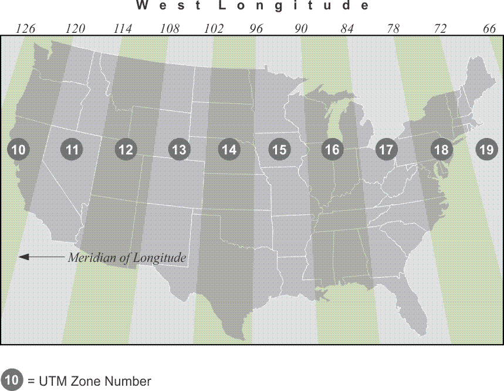

## Geographic (°) vs. Projected (m)

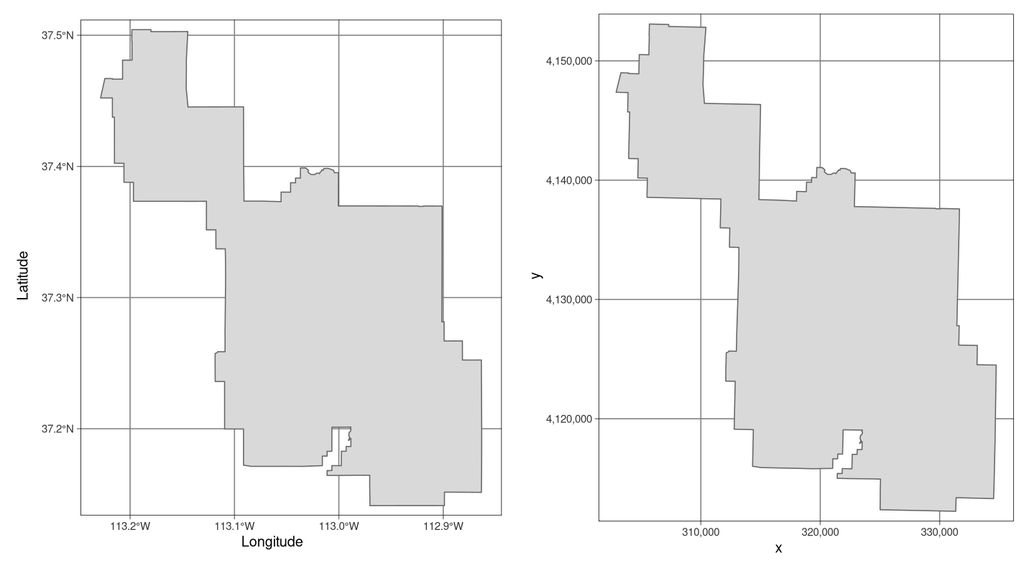

## Quick reference for different CRSs

- EPSG code
- [WGS84](https://epsg.io/4326): EPSG = 4326
- [UTM NAD83 Zone 17N](https://epsg.io/6346): EPSG = 6346

# Quiz time

## Geospatial data types quiz

List each geospatial data layer in the map below (give a descriptive name), and tell me if it is vector or raster. Tip: look closely, there are more than 2.

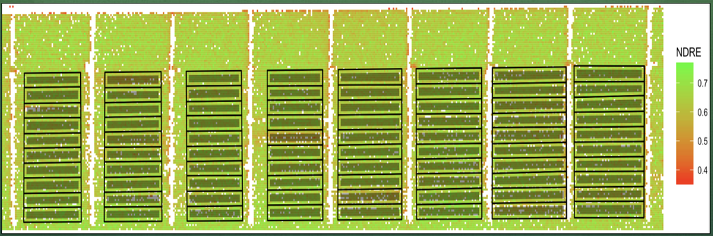

Send me your answer by email to lmbastos@uga.edu. You have **5 min** (this will count for your attendance too).

# USDA National Agricultural Statistics Service (NASS) data

## USDA NASS

- LOTS of information about US agriculture
- Some examples:
  - planted and harvested area time series
  - yield time series
  - production time series
- For lots of different crops, and different geographic levels (from county to nation)

## USDA NASS QuickStats portal

- USDA portal to query and download NASS data
- Free, open source data
- Feel free to explore following [this link](https://quickstats.nass.usda.gov)

[figure not shown]

## Advanced PA and NASS

Let’s download some data and bring into R

- Go to the [portal](https://quickstats.nass.usda.gov)
- Let’s query and download data for **soybeans** **production in bushels** in **GA** at the **county level** for **all years** available
- went to browser…

## Query selections

Sector: CROPS  
Group: FIELD CROPS  
Commodity: SOYBEANS  
Category: PRODUCTION  
Data item: PRODUCTION MEASURED IN BU  
Geographic level: COUNTY  
State: GEORGIA  
Year: select all  
Click “Get data”  
Click “Spreadsheet”

## After downloading…

Rename file to `soybeans_nass.csv`  
In your course folder, create “02 NASS” folder  
Inside it, create `data`, `code`, `output`  
Move `soybeans_nass.csv` into `data`  
Launch RStudio, create a new project at the `02 NASS` folder level  
Create a new script file (quarto)  
Let’s explore this data set